# Analysis of Successful Instagram Posts

36-315 Final Project

Neha Chintamaneni, Shelley Kim, Michael Lim, John Su

10 May 2021

# Abstract

Given the popularity of Instagram and the amount of data Instagram collects in terms of users and posts, we wanted to understand the key factors that impact the success of Instagram posts. This information can potentially provide Instagram users with insights on what factors can improve the success of their Instagram posts. To accurately measure the success of an Instagram post, we decided to focus on engagement rate. Unlike other metrics to determine the success of an Instagram post, engagement rate accounts for the ratio of comment and likes based on the user’s number of followers ($\text{Engagement rate} = \text{Likes}+\text{comments}/\text{followers}$). By accounting for the total number of followers, we can more accurately measure an individual post’s success, since it is self-evident that users with more followers will have more likes and comments on posts. Understanding engagement rate can provide information about audience interests and social proof, especially for influencers or users looking to grow their accounts. In terms of audience interests, if a post appeals more to one’s target audience, this results in a higher engagement rate. In terms of social proof, many brands calculate engagement rate for influencer’s posts to determine whether or not to partner with the influencer. Our overall goal of analyzing engagement rate is to determine which factors can influence engagement rate to help users and potential influencers improve their Instagram posts.

# Data

With our objective in mind, we used a dataset that includes information about posts in various countries, but happened to primarily focus on posts posted in Greece (sourced from [here](https://github.com/gvsi/instagram-like-predictor)). The dataset contains information about 30,000 posts from 1809 unique users. Each of the 30,000 observations in the dataset defines a unique post with 14 columns providing information about each post. Each variable is defined below:

1. Username: the username of the creator of the post (categorical)
2. Followers: Number of Followers(quantitative)
3. Following: Number of accounts followed by the account that made the post (quantitative)
4. Likes: Number of likes on the post (quantitative)
5. Comments: Number of comments on the post (quantitative)
6. Text: Contents of the post description (categorical)
7. Number of Tags: Number of tags on the post (quantitative)
8. List of Tags: List of tags on the post (categorical)
9. Date: the date and time of the post (quantitative)
10. Day:(0 Monday, 6 Sunday): The day of week the post was made (categorical)
11. Type(1 Photo, 2 Video): Whether the post was a video or photo (categorical)
12. Users in Photo: number of users tagged in the post (quantitative)
13. Link: url to Instagram post (categorical)
14. Location: Latitude and longitude of the post’s location (quantitative)

# Research Questions

To fully answer our main objective, we broke it down into various research questions regarding engagement rate and other factors.

- Does engagement rate differ between photos and videos across locations in Greece? (The question chooses to focus on Greece since that is where most of the data originates from.)
- When is the best time of day and day of week to post to maximize engagement rate?
- Does the number of people tagged in the post result in a higher engagement rate?
- How does engagement rate change over posts containing the 20 most common tags? Does engagement rate change whether a post contains any of the 20 most common tags?
- How does word sentiment differ between posts above or below the median engagement rate?

We explore each question and relationship between variables in several different visualizations below.

# Factors Contributing to Higher Post Engagement Rate

## Post Media Type and Location

As a user, one would want to know whether or not the location and type of post can affect its success. Thus, to begin answering our research question “Does engagement rate differ between photos and videos across locations in Greece?” we first wanted to understand the density distribution of engagement rate for photos versus videos to see how the type of post contributes to a greater engagement rate.

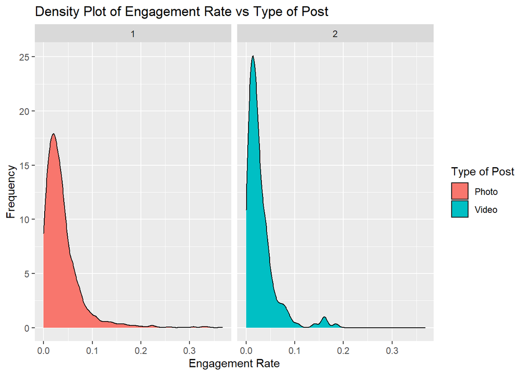

Users in Greece may want to see where to post and what type of post would contribute to a more successful post. Thus, in order to answer our research question “Does engagement rate differ between photos and videos across locations in Greece?” we have decided to focus our analysis on the following variables: engagement rate, whether or not a post is a video or photo, longitude and latitude.

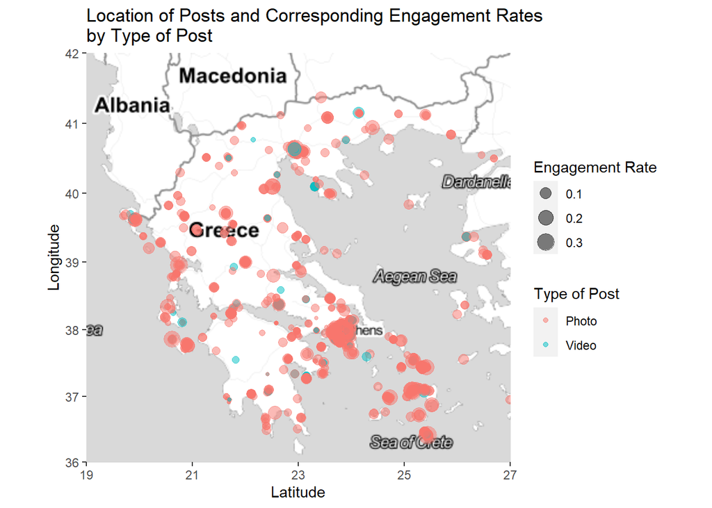

We can see that engagement rate differs with the post’s location and type. In areas close to major cities, there is a greater amount of posts with a higher engagement rate. For example, the post with the greatest engagement rate in Greece was posted in Athens, which is the capital of Greece and its most populated city. Similarly, many of the posts near Athens also have higher engagement rates, specifically for photo posts rather than video posts. On the other hand, we can see that regions that are not in major cities had lower engagement rates.

Since there are more photos than videos, it is hard to state whether or not engagement rate differs between photos and videos with location. Thus, we compare the effect of type of post on engagement rate based on locations that have both video posts and photo posts. The overall trend appears to be that photos receive more engagement than videos. We see that the engagement rate for videos is much lower than the engagement rates for most photos near Kalamaria, Athens, and Crete. Although there are a few locations where there were video posts and photo posts that had equal engagement rates, photos predominantly had higher engagement rates than videos overall.

## Time of Day and Day of Week

The time that a post was uploaded is also a factor in its success. A post made in the early morning may be seen by fewer users than a post made in the afternoon, since people are asleep in the former while active online in the latter. We answer our research question “When is the best time of day and day of week to post to maximize engagement rate?” by plotting engagement rate against time of day.

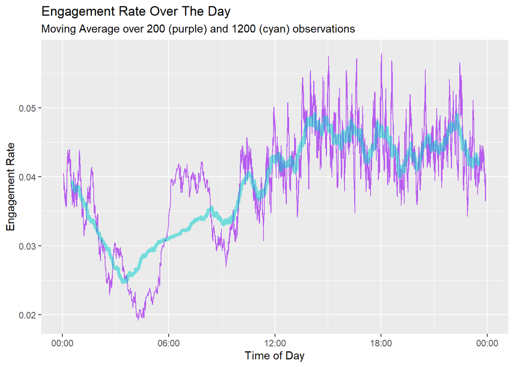

The graph depicted the engagement rate for photos posted during the different times of the day, shown averaging for 200 and 1200 observations, which span over roughly 10 minutes and 1 hour, respectively. The graph contains a major peak around 2 PM and smaller peaks around 6 PM and 10 PM, and the overall trend makes very intuitive sense. Since a photo appears on the top of other users’ feed once it is posted, thus a photo usually gets most of its engagement and attention around the time it is posted. We can see a decline in general engagement from about midnight to 4 AM due to people going to sleep, then the engagement has a gross trend of increasing after 4 AM and peaks around 2 PM, which is the most active time during the day. There is a small decline after the 2 PM peak and the afternoon engagement fluctuates around a similar level with the second minor peak around 6 PM which is likely the time for most people to get off work, and another minor peak at around 10 PM which is likely the time when people get home and get on the phone to relax, and go down after that since people are going to sleep again. The trend quite nicely illustrates the active engagement of Instagram users over a day which matches the intuitive interpretation of the daily routine of many regular people.

The day of the week can also affect the engagement rate, e.g. people have more free time on the weekends and may interact with more posts. To further answer the research question of how time impacts engagement rate, we again visualize trends of engagement rate over time, now divided by day of week.

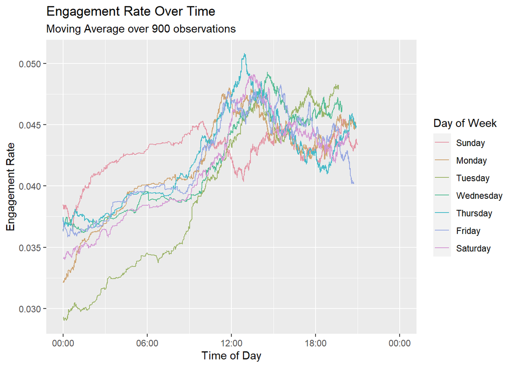

The plot appears to show that engagement rate is highest in the afternoon and lowest in the early morning, and that no single day of the week is the best or worst over the course of the entire day; there is especially little order during the afternoon and evening. We note that Sunday has greater engagement rates in the early morning compared to other days of the week. The time and day of the highest engagement rates occurred around Thursday at noon, and the lowest was on Tuesday early morning. The overall trends of the graph suggest that the day of week does not correlate much with engagement rate while the time of day does.

## Tagging Other Users

One interesting idea is that we see that many popular accounts’ posts may have many people or tagged users in their photos. Tagging another person in the photo may draw more attention from people such as that tagged friend to like and comment. We want to understand if there is any basic connection between the number of tagged users vs. the engagement rate for the user. Thus, in order to answer our research question “Does the number of people tagged in the post result in a higher engagement rate?” we have decided to focus our analysis on the following variables: number of people tagged in a post and engagement rate.

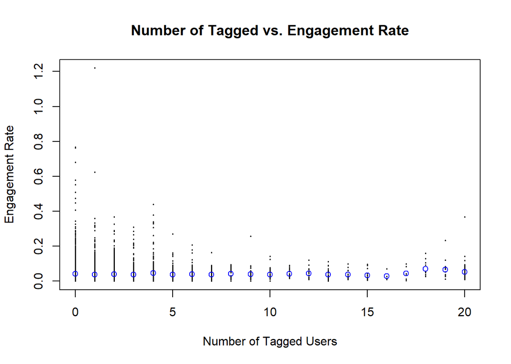

We plotted a scatter plot of the number of tagged users versus the engagement rate. The average engagement rate for each number of tagged users is shown as the blue dots. We can first see that the distribution and range differs between each number of tagged users, the engagement rating appears to be right-skewed at photos that have fewer tagged users. We chose this visualization instead of a parallel box plot to show that the number of posts in each number of tagged users are different here as well; the majority of photos have less than 8 tagged users. The engagement rate average differs only slightly across the number of tagged users which most appears in photos that have more than 7 users, and for users with 0 to 7 tagged users the average appears to be at around the same level. We will do an ANOVA test in the later analysis paper to validate our graph observations.

## Use of Common Hashtags

We want to know what hashtags to use and how many to use to improve success. To do so, we looked at the most commonly used hashtags and the number of hashtags used in relation to engagement rate. In order to answer our research question “How does engagement rate change over posts containing the 20 most common hashtags? Does engagement rate change whether a post contains any of the 20 most common hashtags?” we have decided to focus our analysis on the following variables: number of hashtags in a post, engagement rate, and whether or not a post contains the 20 most common hashtags.

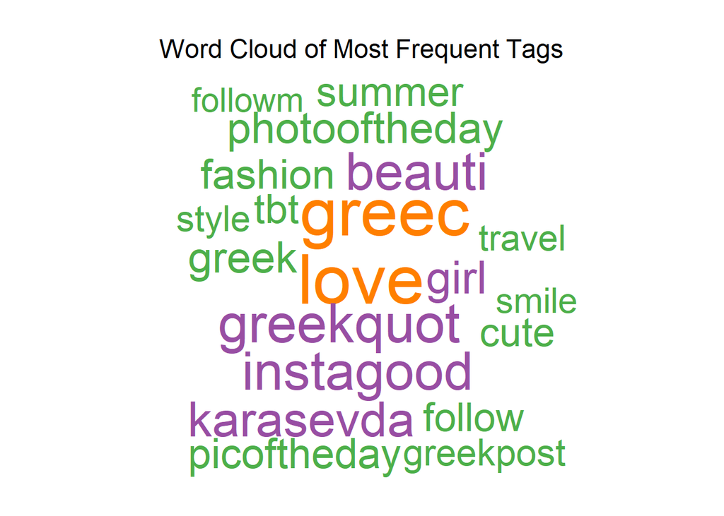

The word cloud shows the 20 most frequent tags. There are instagram specific tags (“instagood”, “photooftheday”, “follow”), common words (“smile”, “cute”, “fashion”) as well as words relating to Greece (“greec”, “greekquot”, “greek”). Some words appear to be cut off at the end due to word stemming.

To examine the engagement rates of posts with the most frequent hashtags, we plotted a bar graph, shown below.

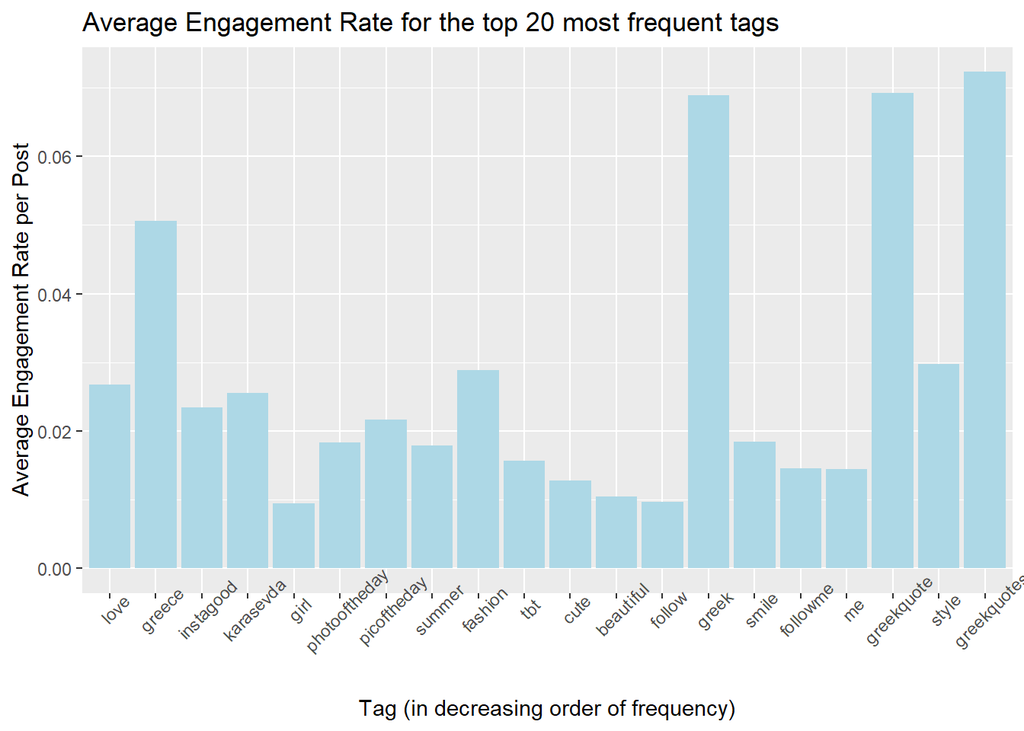

At glance, engagement rate of a post does not appear to be closely related to the frequency rank of the tag in the post. There are some tags that result in higher engagement rates however, and those tags are notably related to Greece: Posts containing “Greece”, “Greek”, “Greekquote”, and “GreekQuoter” have higher engagement rates.

We wanted to see whether the engagement rate changed based off of the presence of one of the frequent hashtags, visualized with a scatterplot and trendline.

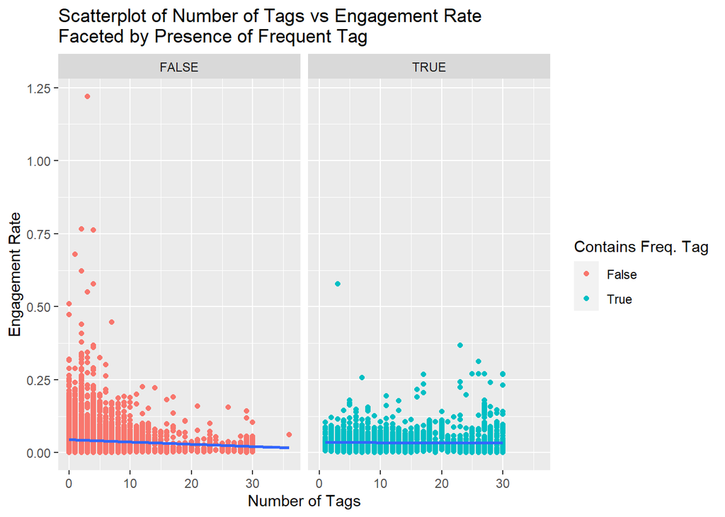

In the scatterplot we see that posts that do not contain a frequent hashtag have higher engagement rates when fewer hashtags are used and lower engagement rates when more hashtags are used. Conversely, when a post does contain a frequent hashtag, the distribution of engagement rate is relatively flat across the number of hashtags. It does appear that highest engagement rates occur when either the post has a low number of hashtags and does not contain a frequent hashtag, and also when a post has a large number of hashtags and does contain a frequent hashtag. Closer analysis is needed to determine if the higher engagement rate is because of a few outliers, or there really are a select few hashtags that result in higher engagement rates.

## Post Text Sentiment

Posts also have a text description, and the sentiment of words in the post may be a contributing factor to the post’s success. To explore possible difference in what types of positive and negative sentiment words are used by more or less successful posts, we divided posts into posts that had less than or greater than or equal to the median engagement rate (about 2.8%), parsed the text of the posts, and compared the sentiments of words in those posts.

Below is a word cloud of positive and negative sentiments of words in posts with less than the median engagement rate:

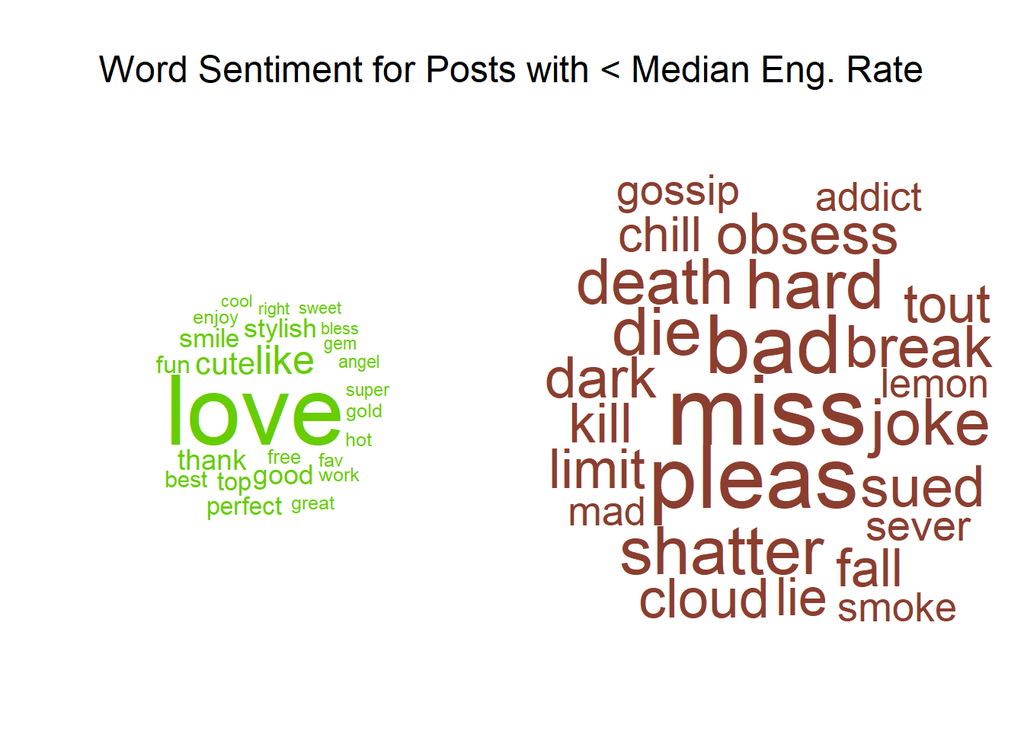

Below is a word cloud of positive and negative sentiments of words in posts with greater than or equal to the median engagement rate:

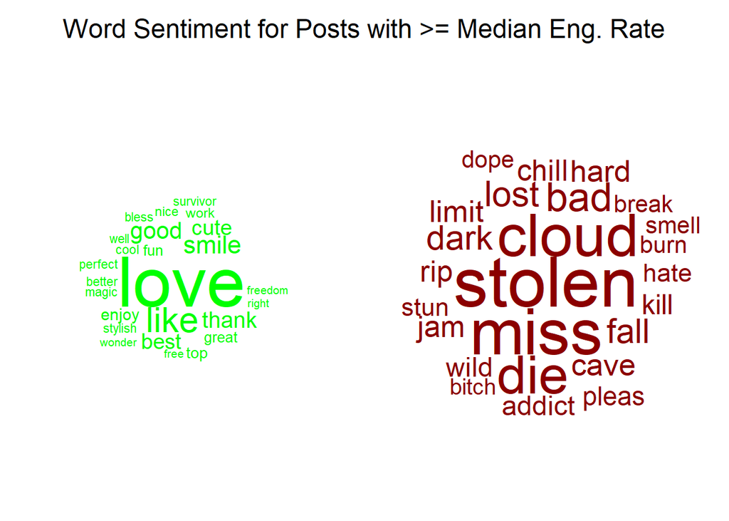

|  | >Median | <=Median |
| --- | --- | --- |
| Positive | 0.8154 | 0.8027 |
| Negative | 0.1846 | 0.1973 |

It is difficult to interpret the sentiment of posts online since word usage on the internet is highly variable. The sentence “This joke killed me, rip” would be labeled as having several negative sentiment words by our sentiment dictionary when in reality it is a positive statement, the word “cloud” may be used to describe a photo of a landscape, the word “addict” or “obsess” may be used to say that the author enjoys something very much, so forth. While we cannot draw any conclusions between word sentiment and actual post sentiment, we may conclude that posts with both levels of engagement rate use similar positive words but different negative words.

# Conclusion

By visualizing how engagement rate changes over different variables, we deduced that certain factors contribute to a post’s engagement rate while others had little to no effect. We found that photos had higher engagement rates than videos and that posts made in cities had higher engagement rates. Additionally, we found that the best time of day to post is in the afternoon, around 12PM - 3PM, but the day of week of the post did not have a clear trend. The number of users tagged did not appear to have a relationship with engagement rate.

Words used in the post were found to have varying but overall inconclusive effects on post engagement rate. Certain hashtags such as “Greece”, “Greek”, and “Greekquote” contributed to a higher engagement rate for posts within our dataset, though this is due to our dataset having a high number of posts from Greece; we would not conclude that Greek hashtags result in higher engagement rates globally. The relationship between number of hashtags and engagement rate compared between posts that did or did not include common hashtags was also explored, but showed little correlation. Within post text, usage of positive-sentiment words was similar across posts with different values of engagement rate.

In conclusion, it appears that factors surrounding the post’s creation, such as location, time of day, and medium, have a greater impact on its engagement rate than the post’s content itself. Further work may entail research on datasets without regional limitations as this project’s dataset did.